# `perglm_test()` validation

Recorded guard cases pass; Gaussian/Poisson study completed

Run completed November 18, 2026 at 07:46:02 PM EST. Package 0.0.0.9000; R version 4.4.1 Patched (2024-06-25 r86831).

**22**simulation cells

**22,000**requested datasets

**499**permutations per successful call

**0**unresolved edge-probe failures

This is a finite simulation study and an implementation audit. It does not prove calibration for all distributions, sample sizes, or model choices. Every requested dataset is retained; failures give no decision and count as no rejection in unconditional rates.

## Guard regression checks

**20 of 20 recorded deterministic probes meet their stated expected behavior; 0 remain failing.** Expected errors and finite positive controls are both retained.

Earlier validation identified complete/quasi separation in Bernoulli models and roundoff-only scores from nonconstant exact Gaussian fits. Those defects motivated explicit fit-validation guards. The table below reports their current rerun status rather than carrying forward the earlier failure count.

Fit-validation checks run once during null-score preparation. The permutation engine reuses the prepared quantities across all draws.

- **Bernoulli separation:** `check_glm_separation()` calls `detectseparation::detect_separation()` using a logit geometry proxy and the column-normalized free design. Fixed offsets are excluded from separation directions; the requested family, link, and offset remain in the actual model fit. The result records `null_diagnostics$separation_checked`.
- **Gaussian residuals:** `gaussian_fit_diagnostics()` compares fitted-response residual variation with a bound derived from prediction-arithmetic roundoff, including nonconstant outcomes and fixed offsets. The relative arithmetic envelope uses `gamma_k = k*u/(1-k*u)`, with `k = 4*(p+2)`, `u = .Machine$double.eps/2`, and nuisance-design dimension `p`. The result records `null_diagnostics$gaussian_residual_check`, including `residual_norm`, `roundoff_bound`, and `relative_residual_norm`.

| Check | Cases | Expected behavior met | Remaining failures |
| --- | --- | --- | --- |
| Bernoulli separation examples | 9 | 9 | 0 |
| Nonconstant exact Gaussian fits | 2 | 2 | 0 |
| Endpoint, constant-response, and other guards | 8 | 8 | 0 |
| Interior/noisy positive controls | 1 | 1 | 0 |

All currently recorded guard and positive-control probes pass. This verifies the listed cases and does not establish coverage of every possible design or numerical boundary.

An optional archived before/after comparison records identical complete replicate tables across 22,000 simulated datasets after adding the guards. Read the recorded comparison. This comparison uses an archived earlier run; it is separate from the current-run reproduction commands below.

## Implementation and exact-reference checks

92 tests; 1005 expectations passed; 0 failures, 0 errors, 0 warnings, 0 skips.

`R CMD check --no-manual --no-build-vignettes`: Status: OK Read the package-check log.

Existing public-API tests exercise default and custom fitting controls, batch-size and statistic-retention reproducibility, and agreement of final RNG states with independent calculations. The simulation below uses the study-specific settings listed explicitly.

Saved raw results, counts, rejection indicators, plus-one p-values, replicate seeds, and exact binomial intervals were rechecked. All source-file hashes match the simulation snapshot.

The independent balanced-label check exhausts all 70 allocations of four treated labels among eight fixed outcomes. Group mean differences provide the reference ranking. Public observed scores were checked for every allocation; the full-orbit p-value helper was checked for all three alternatives. Nine seeded public Monte Carlo runs (199 permutations each) were also compared draw by draw, including p-values and RNG state.

| check | value | passed |
| --- | --- | --- |
| balanced_allocations | 70 | TRUE |
| distinct_signed_group_differences | 70 | TRUE |
| distinct_absolute_group_differences | 35 | TRUE |
| observed_score_scaled_error | 2.22044604925031e-16 | TRUE |
| reference_orbit_p_mismatches | 0 | TRUE |
| public_orbit_p_mismatches | 0 | TRUE |
| exact_rejection_fraction_violations | 0 | TRUE |
| mc_score_scaled_error | 2.22044604925031e-16 | TRUE |
| mc_p_value_mismatches | 0 | TRUE |
| mc_rng_mismatches | 0 | TRUE |
| mc_unmapped_runs | 0 | TRUE |

Exact rejection fractions over this fixed orbit:

| alternative | alpha | group_rejection_fraction | reference_rejection_fraction | public_rejection_fraction | all_at_most_alpha |
| --- | --- | --- | --- | --- | --- |
| greater | 0.05 | 0.0428571428571429 | 0.0428571428571429 | 0.0428571428571429 | TRUE |
| greater | 0.1 | 0.1 | 0.1 | 0.1 | TRUE |
| greater | 0.2 | 0.2 | 0.2 | 0.2 | TRUE |
| less | 0.05 | 0.0428571428571429 | 0.0428571428571429 | 0.0428571428571429 | TRUE |
| less | 0.1 | 0.1 | 0.1 | 0.1 | TRUE |
| less | 0.2 | 0.2 | 0.2 | 0.2 | TRUE |
| two.sided | 0.05 | 0.0285714285714286 | 0.0285714285714286 | 0.0285714285714286 | TRUE |
| two.sided | 0.1 | 0.0857142857142857 | 0.0857142857142857 | 0.0857142857142857 | TRUE |
| two.sided | 0.2 | 0.2 | 0.2 | 0.2 | TRUE |

References: metrics, all allocations, full-orbit p-values, Monte Carlo runs.

## Simulation design

Each cell uses 1000 independent datasets, a two-sided test, nominal level 0.05, and 499 independently sampled permutations. Study-specific fitting controls are `epsilon = 1e-10` and `maxit = 100`, with `alternative = "two.sided"`, `batch_size = 64`, and `keep_statistics = FALSE`. This uses a tighter convergence tolerance and a larger iteration limit than the public defaults; the study evaluates this specified configuration. There were 0 errors across the 20,000 regular-null/power datasets; the 912 sparse-exposure failures are reported separately below. Two bounded nuisance covariates U and V are independent Uniform[-1,1]. Ordinary exposures have prevalence 0.3 under marginal independence (MI), or Bernoulli probability expit(logit(0.3) + 1.2U - 0.8V) in confounded conditional-mean (CM) cells. The fitted null is always `y ~ u + v`.

Gaussian means are 0.4 + 0.6U - 0.4V + gamma X; Poisson log means are 0.2 + 0.5U - 0.3V + gamma X. MI cases add an omitted 0.6U^2 term while keeping X independent of (Y,U,V). CM cases retain the correct fitted null mean. The Gaussian heteroskedastic cell uses SD = exp(0.5U + 0.3X): its conditional mean null holds, while conditional independence is false because variance depends on X. The Poisson variance-misspecification cell generates negative-binomial outcomes with size 2 and the correct Poisson working mean.

Gaussian power coefficients are 0.25 and 0.5; Poisson coefficients are 0.3 and 0.6. Sample sizes are 100 and 500. Separate sparse-exposure stress cases use n = 40 and independent X ~ Bernoulli(0.02).

## Null calibration

None of the 12 regular null cells shows detected excess rejection after the Bonferroni adjustment. The familywise check uses a one-sided binomial excess tail multiplied by 12; only adjusted p-values below 0.05 flag excess rejection. The plotted intervals are 95% pointwise exact binomial intervals and are not simultaneous bands.

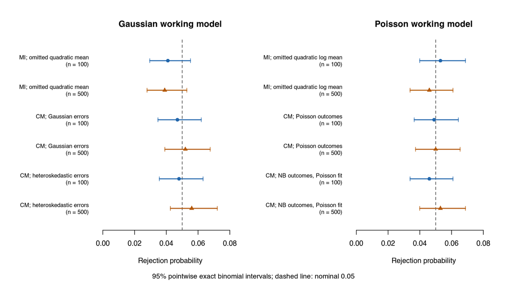

Download null-calibration figure · Download multiplicity checks

| Scenario | n | Rejected / requested | Errors | Rejection rate | 95% pointwise CI | Adjusted excess p | Excess flag |
| --- | --- | --- | --- | --- | --- | --- | --- |
| MI; omitted quadratic mean | 100 | 41 / 1000 | 0 | 4.1% | [3.0%, 5.5%] | 1.0000 | No |
| MI; omitted quadratic mean | 500 | 39 / 1000 | 0 | 3.9% | [2.8%, 5.3%] | 1.0000 | No |
| CM; Gaussian errors | 100 | 47 / 1000 | 0 | 4.7% | [3.5%, 6.2%] | 1.0000 | No |
| CM; Gaussian errors | 500 | 52 / 1000 | 0 | 5.2% | [3.9%, 6.8%] | 1.0000 | No |
| CM; heteroskedastic errors | 100 | 48 / 1000 | 0 | 4.8% | [3.6%, 6.3%] | 1.0000 | No |
| CM; heteroskedastic errors | 500 | 56 / 1000 | 0 | 5.6% | [4.3%, 7.2%] | 1.0000 | No |
| MI; omitted quadratic log mean | 100 | 53 / 1000 | 0 | 5.3% | [4.0%, 6.9%] | 1.0000 | No |
| MI; omitted quadratic log mean | 500 | 46 / 1000 | 0 | 4.6% | [3.4%, 6.1%] | 1.0000 | No |
| CM; Poisson outcomes | 100 | 49 / 1000 | 0 | 4.9% | [3.6%, 6.4%] | 1.0000 | No |
| CM; Poisson outcomes | 500 | 50 / 1000 | 0 | 5.0% | [3.7%, 6.5%] | 1.0000 | No |
| CM; NB outcomes, Poisson fit | 100 | 46 / 1000 | 0 | 4.6% | [3.4%, 6.1%] | 1.0000 | No |
| CM; NB outcomes, Poisson fit | 500 | 53 / 1000 | 0 | 5.3% | [4.0%, 6.9%] | 1.0000 | No |

## Power

The zero-effect points are the correctly specified confounded-CM null cells. Each positive-effect cell has its own independent datasets and seeds. Intervals describe repeated-dataset rejection probabilities.

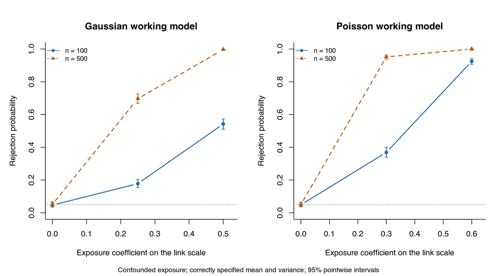

Download power figure

| Family | n | gamma | Rejected / requested | Errors | Power | 95% pointwise CI |
| --- | --- | --- | --- | --- | --- | --- |
| gaussian | 100 | 0.25 | 178 / 1000 | 0 | 17.8% | [15.5%, 20.3%] |
| gaussian | 500 | 0.25 | 697 / 1000 | 0 | 69.7% | [66.7%, 72.5%] |
| gaussian | 100 | 0.5 | 542 / 1000 | 0 | 54.2% | [51.1%, 57.3%] |
| gaussian | 500 | 0.5 | 997 / 1000 | 0 | 99.7% | [99.1%, 99.9%] |
| poisson | 100 | 0.3 | 369 / 1000 | 0 | 36.9% | [33.9%, 40.0%] |
| poisson | 500 | 0.3 | 952 / 1000 | 0 | 95.2% | [93.7%, 96.4%] |
| poisson | 100 | 0.6 | 925 / 1000 | 0 | 92.5% | [90.7%, 94.1%] |
| poisson | 500 | 0.6 | 1000 / 1000 | 0 | 100.0% | [99.6%, 100.0%] |

## Sparse-exposure failures and difficult inputs

With n = 40 and exposure prevalence 0.02, the probability that X is constant is 44.6% (0.98^40 + 0.02^40). Such datasets have no identifiable exposure contrast. Observed errors and messages are reported below. Successful-call rejection rates are descriptive and do not establish validity conditional on successful completion.

| Scenario | n | Requested | Successful | Errors | Error rate | Unconditional rejection | 95% pointwise CI | Rejection among successful calls |
| --- | --- | --- | --- | --- | --- | --- | --- | --- |
| Rare binary X; Gaussian | 40 | 1000 | 523 | 477 | 47.7% | 2.2% | [1.4%, 3.3%] | 4.2% |
| Rare binary X; Poisson | 40 | 1000 | 565 | 435 | 43.5% | 1.8% | [1.1%, 2.8%] | 3.2% |

| case_id | error | datasets |
| --- | --- | --- |
| gaussian_rare_x_n40_gamma0 | exposure has no numerically identifiable variation after nuisance adjustment. | 477 |
| poisson_rare_x_n40_gamma0 | exposure has no numerically identifiable variation after nuisance adjustment. | 435 |

Deterministic public-API tests cover boundary responses (all-zero counts, all-zero/all-one Bernoulli outcomes), constant outcomes with constant offsets, row alignment, nuisance aliases, all supported families, fixed offsets, and decreasing links. Constant outcomes with a varying offset can remain informative and are checked against an independent fitted-model reference.

Download all deterministic edge probes · Probe session information

| case | family | link | expected | observed | passed | p_value | notes |
| --- | --- | --- | --- | --- | --- | --- | --- |
| poisson_all_zero | poisson | log | error: no finite null-model MLE | error | TRUE | NA | Exact all-zero count guard; response has no finite log-link intercept MLE. |
| binomial_all_zero | binomial | logit | error: no finite null-model MLE | error | TRUE | NA | Exact Bernoulli endpoint guard; both response classes are required. |
| fixed_NB_all_zero | negative.binomial | log | error: no finite null-model MLE | error | TRUE | NA | Fixed-size NB with an all-zero response; theta = 1.7. |
| binomial_all_one | binomial | logit | error: no finite null-model MLE | error | TRUE | NA | Exact Bernoulli endpoint guard. |
| Gaussian_constant_no_offset | gaussian | identity | error: zero empirical score variance | error | TRUE | NA | Constant response and an intercept imply exactly zero outcome scores. |
| Gaussian_constant_constant_offset | gaussian | identity | error: zero empirical score variance | error | TRUE | NA | A constant known offset is absorbed by the intercept. |
| poisson_constant_positive | poisson | log | error: zero empirical score variance | error | TRUE | NA | Positive constant counts admit an exact common-mean fit. |
| fixed_NB_constant_positive | negative.binomial | log | error: zero empirical score variance | error | TRUE | NA | Fixed-size NB admits an exact common-mean fit; theta = 1.7. |
| complete_logit | binomial | logit | error: no finite null-model MLE | error | TRUE | NA | Complete separation: direction (intercept = 0, z = 1) has strictly positive signed margins. The separation guard must reject even if glm() reports convergence at maxit = 200. |
| quasi_factor_logit | binomial | logit | error: no finite null-model MLE | error | TRUE | NA | Quasi separation: pure-cell indicator direction (0, 1) has signed margin zero on the mixed cell and one on all 20 pure-one rows. |
| complete_probit | binomial | probit | error: no finite null-model MLE | error | TRUE | NA | Complete separation: direction (intercept = 0, z = 1) has strictly positive signed margins. The separation guard must reject even if glm() reports convergence at maxit = 200. |
| quasi_factor_probit | binomial | probit | error: no finite null-model MLE | error | TRUE | NA | Quasi separation: pure-cell indicator direction (0, 1) has signed margin zero on the mixed cell and one on all 20 pure-one rows. |
| complete_cauchit | binomial | cauchit | error: no finite null-model MLE | error | TRUE | NA | Complete separation: direction (intercept = 0, z = 1) has strictly positive signed margins. The separation guard must reject even if glm() reports convergence at maxit = 200. |
| quasi_factor_cauchit | binomial | cauchit | error: no finite null-model MLE | error | TRUE | NA | Quasi separation: pure-cell indicator direction (0, 1) has signed margin zero on the mixed cell and one on all 20 pure-one rows. |
| complete_cloglog | binomial | cloglog | error: no finite null-model MLE | error | TRUE | NA | Complete separation: direction (intercept = 0, z = 1) has strictly positive signed margins. The separation guard must reject even if glm() reports convergence at maxit = 200. |
| quasi_factor_cloglog | binomial | cloglog | error: no finite null-model MLE | error | TRUE | NA | Quasi separation: pure-cell indicator direction (0, 1) has signed margin zero on the mixed cell and one on all 20 pure-one rows. |
| complete_cauchit_default_control | binomial | cauchit | error: no finite null-model MLE | error | TRUE | NA | Default maxit = 25 rejects nonconvergence; the separation guard also rejects converged fits at larger maxit. |
| Gaussian_exact_nonconstant_linear | gaussian | identity | error: zero empirical score variance | error | TRUE | NA | Exact y = 2 + 3*z has zero mathematical score variance; floating QR residuals are checked against the prediction-roundoff envelope. |
| Gaussian_exact_two_groups | gaussian | identity | error: zero empirical score variance | error | TRUE | NA | Exact y = 3 + 2*z; the residual-resolution guard must reject projection roundoff. |
| binomial_offset_only_classification | binomial | logit | finite p-value: valid interior fit | returned_p_value | TRUE | 1 | Known offsets classify all rows, but the sole free intercept has a finite MLE. Separation witnesses must exclude the fixed offset. |

No simulation dataset produced a warning.

## Reproducibility and data

RNG: Mersenne-Twister / Inversion / Rejection. Base seed: 20261118. Data and permutation seeds are stored for every replicate. The simulation uses the recorded installed package; reinstall this source version into that library before reproduction.

```
R_LIBS=/private/tmp/perglm-guards-lib Rscript validation/validate-perglm.R --repetitions=1000 --B=499 --workers=2 --output=validation/results
R_LIBS=/private/tmp/perglm-guards-lib Rscript validation/exact-reference.R
R_LIBS=/private/tmp/perglm-guards-lib Rscript validation/edge-probes.R
Rscript validation/summarize-validation.R --results=validation/results --exact=validation/exact-results
```

All 22 cell summaries · Every replicate (compressed CSV) · Scenario specifications · Automated-test summary · R session information · Run configuration

**Verified source hashes**

| File | MD5 |
| --- | --- |
| R/glm_fit_diagnostics.R | a93109af156981cfc005260ec2a7b7e0 |
| R/glm_null.R | 4dcc021a2d7de6515c89d909f1db041f |
| R/glm_permutation.R | e1c1a75be8db9fc259b76aa7f18d6634 |
| R/glm_score_statistic.R | f794c3f453ef2eed23114188a7d125b6 |
| R/glm_score.R | a7c71fc91a89714b2adf07abd37329aa |
| R/glm_separation.R | 74fc7b8eee6b4b84b253cac52433345e |
| R/perglm_test.R | ea1663a06148d8d9f54eac9424e7ecba |
| R/perglm-package.R | 314f99fb458a2318ad6a6030ebcf0239 |
| R/permutation_p_value.R | 6c44b7737109d76c0fe3bb8ee752e115 |
| R/RcppExports.R | 5536e5014cac387ae3d07c8624f233e4 |
| R/score_studentization.R | f88d493cf27431157bc0a7109da07934 |
| R/weighted_projection.R | 93aa0e9764142285a8b8f30bfd127b71 |
| src/Makevars | 2fa4c7011c2bc0f7449ae151d5cc44ae |
| src/Makevars.win | 2fa4c7011c2bc0f7449ae151d5cc44ae |
| src/projection_score.cpp | ea629e23b14e39c8f361ad2d4387d2b3 |
| src/RcppExports.cpp | 85cb21bf5e0326424ba123ede5e47ea9 |
| src/studentize.cpp | 2b94c91341b5ee9d65ef1f611e9a13c5 |
| src/studentize.h | 90db2458d0dec896df2cbec4bd2c0162 |
| validation/validate-perglm.R | 9e1f7d9fda763adee82509dc3eeed6de |
| DESCRIPTION | 03e45fe71e68e58a4c9c0db39ecfd3c9 |
| NAMESPACE | 5017ada647ad51a950ca752c8673d774 |

Installed simulation package: `/private/tmp/perglm-guards-lib/perglm`. Simulation wall time: 202.7 seconds. Analyzer MD5: `ac6e58fb16b623f009571edf3efeab5d`.